# proDA analysis of Virology data (proteins interaction - BioID data)

Philippe Hauchamps

December 5th, 2019

## Goal of this report

The goal of this report is to analyze protein intensity data from a Virology BioID protein interaction experiment.

Input data are taken from a set of files processed by MaxQuant platform. We concentrate on the so-called ‘L’ experiment and consider the 3 different conditions :

- Wild Type (WT)
- Mutated M60V
- Mutated F48A

There might be a batch effect, since among the 3 replicates per condition, one was produced first, and the two others in a subsequent batch.

M60V serves as negative control and should be compared against the two other conditions, where we would like to identify the differentially abundant proteins.

Questions of interest :

- which proteins are significantly differentially abundant in WT vs. M60V ?
- among these, do we see an enrichment for the proteins belonging to FG-NUP group? (see below for a definition of this group)
- same two questions for F48A vs. M60V

In order to cope with high proportion of missing data (not at random), we use the proDA package which :

- belongs to the class of empirical bayes methods
- models the missingness process explicitly, and link it to the latent protein intensities.

## Read MaxQuant data - build MSnSet object

While importing the MaxQuant data into an MSnSet object, we filter out :

- identified contaminants
- identified reverse sequences
- proteins which do not have any positive intensity for any sample.

After filtering, we obtain intensities for 997 proteins.

Indeed we have 9 samples, i.e. 3 conditions and 3 replicates per condition.

```r
f <- "data/MQ20191112/txt/proteinGroups.txt"
#getEcols(f, "\t")

## e <- grepEcols(f, "LFQ ", "\t")
e <- grepEcols(f, "Intensity ", "\t")
# Make MSnSet object
x <- readMSnSet2(f, ecol = e, sep = "\t")
sampleNames(x) <- sub("Intensity.", "", sampleNames(x))
pData(x)$rep <- rep(1:3, 3)
pData(x)$grp <- rep(c("F48A", "M60V", "WT"), each = 3)
pData(x)$grp <- factor(pData(x)$grp, levels = c("M60V", "WT", "F48A"))
pData(x)$batch <- rep(c(1, 2, 2), 3)

featureNames(x) <- fData(x)$Protein.IDs

## Remove contaminants, reverse and no expression
## changed: was ^CON and ^REV
x <- x[-grep("CON", fData(x)[, "Protein.IDs"])]
x <- x[-grep("REV", fData(x)[, "Protein.IDs"])]
x <- x[rowSums(exprs(x)) > 0, ]
nSamples <- nrow(pData(x))
nProteins <- nrow(x)
cat("nSamples : ", nSamples, "\n")
```

```
## nSamples :  9
```

```r
cat("nProteins : ", nProteins, "\n")
```

```
## nProteins :  997
```

## Some exploratory data analysis

### PCA via pRoloc::plot2D

We compute a preliminary PCA, and display the scores of the samples on 2D projections.

Projection on 1 and 2 principal components show that WT samples present much more variability than the samples of M60V and F48A. It seems very difficult to show a clear separation of M60V samples vs. F48A samples. Projection to component 5 and 6 is the better projection we could get for this matter.

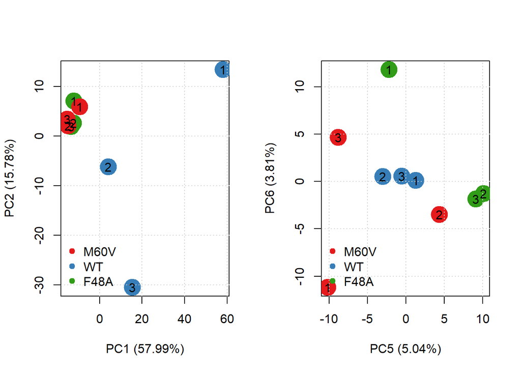

```r
par( mfrow = c(1,2) )
#plot2D(normalise(x, "sum"), fcol = NULL)

.pca <- plot2D(t(x),  fcol = "grp", cex = 3, dims = 1:2)
text(.pca[, 1], .pca[, 2], 1:3)
addLegend(t(x), fcol = "grp")
.pca <- plot2D(t(x),  fcol = "grp", cex = 3, dims = 5:6)
text(.pca[, 1], .pca[, 2], 1:3)
addLegend(t(x), fcol = "grp")
```

### boxplot and density of log( intensities )

We can notice the effect of group and a slight batch effect (1 vs 2-3) as well, especially with the WT group.

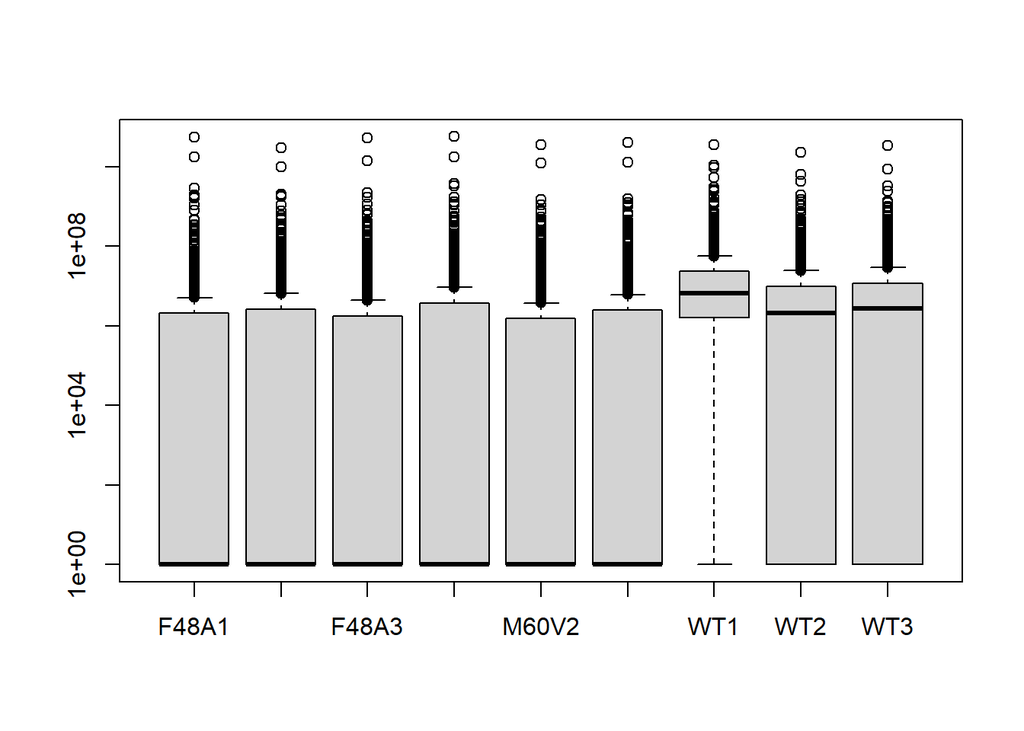

```r
par( mfrow = c(1,1) )
boxplot(exprs(x)+1, log = "y")
```

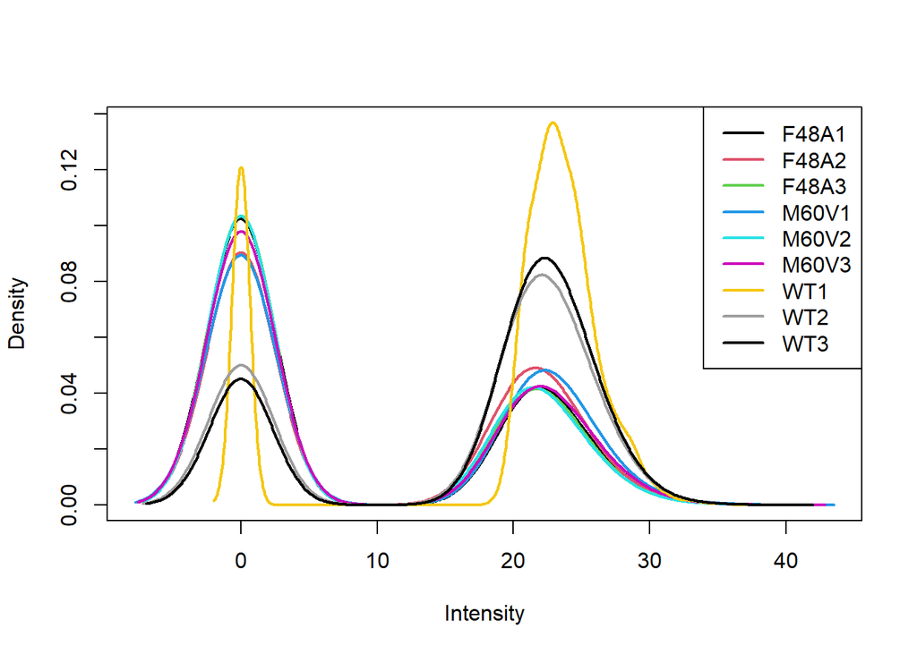

```r
limma::plotDensities(log2(exprs(x) + 1),
                     legend = "topright")
```

### NA’s per sample

```r
# Replace 0 by NA
exprs(x)[exprs(x) == 0] <- NA
pData(x)$nNA <- colSums(is.na(exprs(x)))
fData(x)$nNA <- rowSums(is.na(exprs(x)))

cat("NA's : ", round( 100 * mean( is.na(x) ), 2 ), "%\n" )
```

```
## NA's :  49.43 %
```

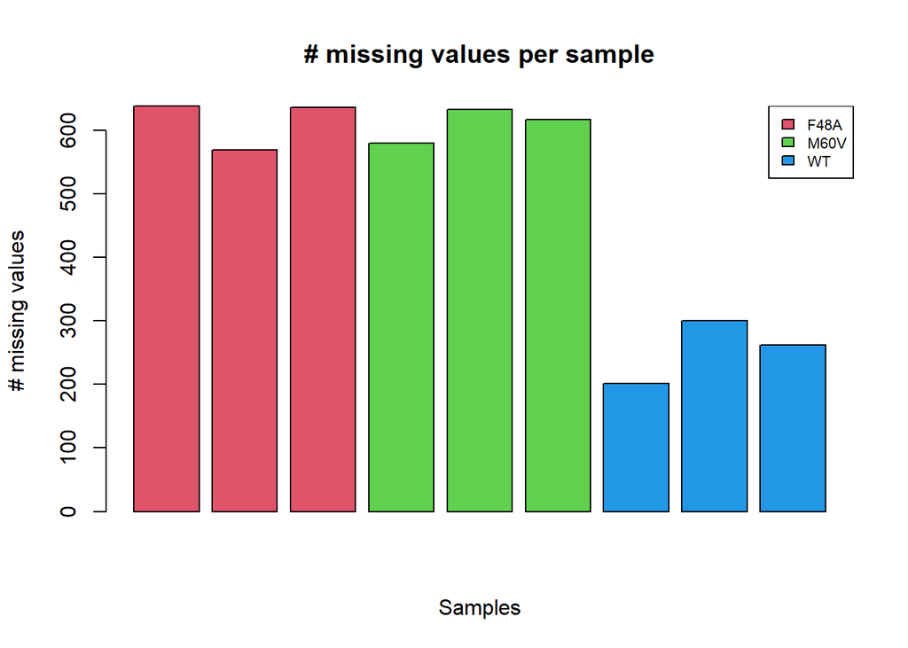

```r
barplot(pData(x)$nNA,
        ylab = "# missing values",
        xlab = "Samples",
        main = "# missing values per sample",
        col = rep(c(2, 3, 4), each = 3))
legend("topright",
       legend=unique( pData( x )$grp ),
       cex = 0.7,
       fill = c(2, 3, 4))
```

## proDA analysis after normalization

We normalize the log2 transformed sample data using translation wrt column (sample) median. We also add a constant, in order to avoid displaying negative values.

```r
norm_log_x <- x %>%
    log(base = 2) %>%
    normalise(method = "center.median" )
exprs(norm_log_x) <- exprs(norm_log_x) + 5 ## to remove negative values
```

We then run proDA analysis on log2 transformed data.  
We run one model fit with only ‘group’ (M60V vs. WT vs. F48A) as covariate and another model with both ‘group’ and ‘batch’ as covariates.

```r
file_name <- "rds/proDA_fit_norm_3grp.rds"
if ( file.exists( file_name )) {
    proDA_fit_norm <- readRDS( file_name )
} else {

    proDA_fit_norm <- proDA( norm_log_x,
                            design = ~ grp,
                            data_is_log_transformed = TRUE,
                            verbose = TRUE)

    saveRDS( proDA_fit_norm, file = file_name )
}

file_name <- "rds/proDA_fit_full_norm_3grp.rds"
if ( file.exists( file_name )) {
    proDA_fit_full_norm <- readRDS( file_name )
} else {
    proDA_fit_full_norm <- proDA( norm_log_x,
                                 design = ~ grp + batch,
                                 data_is_log_transformed = TRUE,
                                 verbose = TRUE)

    saveRDS( proDA_fit_full_norm, file = file_name )
}
```

### Test of the batch effect

From the full model, we test whether the batch effect is significant. First ajusted p-vals are around 0.21. We can therefore remove the batch covariate from the model.

```r
batch_res <- test_diff( proDA_fit_full_norm,
                        contrast = "batch",
                        alternative = "two.sided",
                        pval_adjust_method = "BH",
                        sort_by = "pval" )

head(dplyr::arrange(batch_res, adj_pval))
```

```
##     name         pval  adj_pval      diff t_statistic        se df
## 1 P25705 0.0002144479 0.2138045 -3.264160   -9.537360 0.3422499  5
## 2 Q96M11 0.0004580228 0.2283244  9.026296    8.126103 1.1107780  5
## 3 P05067 0.0010717225 0.2873373 -6.771261   -6.765777 1.0008106  5
## 4 P35030 0.0012169131 0.2873373 -2.466033   -6.580102 0.3747712  5
## 5 Q15645 0.0014410095 0.2873373 -6.070079   -6.339603 0.9574858  5
## 6 Q9Y623 0.0029096812 0.4786724 -4.967407   -5.413777 0.9175494  5
##   avg_abundance n_approx n_obs
## 1      4.209200 8.001510     8
## 2      7.374817 6.327762     6
## 3      3.420313 3.346172     3
## 4      4.127494 6.880779     7
## 5      3.219930 3.377895     3
## 6      3.019308 3.424234     3
```

### LR test of the group effect in the reduced model

We start by testing the ‘group’ effect as a whole (i.e. for all levels simultaneously), using a likelihood ratio test.

We get smallest p-vals around 10e-6 and adjusted p-val between 0.08% and 1.7%

=> it is definitely worthwhile looking at differences for pairs of levels.

```r
grp_res <- test_diff( proDA_fit_norm,
                       reduced_model = ~1,
                       pval_adjust_method = "BH",
                       sort_by = NULL,
                       verbose = F )

dplyr::arrange(grp_res, adj_pval) %>%
    head()
```

```
##                          name         pval    adj_pval f_statistic df1      df2
## 1                      P52948 8.388716e-07 0.000836355   144.13276   2 7.657031
## 2                      O60318 2.368866e-06 0.001180880   156.79676   2 6.698762
## 3                      P35658 6.324209e-06 0.002101746    83.46790   2 7.657031
## 4 Q15418;O60307;Q9Y2H9;Q6P0Q8 1.210513e-05 0.003017203   144.54465   2 5.751585
## 5                      Q9NQW6 4.355105e-05 0.008684080    63.42902   2 6.716597
## 6                      Q8NG31 1.050275e-04 0.017452070    38.07568   2 7.657031
##   avg_abundance n_approx n_obs
## 1     11.602686 9.000000     9
## 2      7.405464 8.041732     8
## 3     10.127872 9.000000     9
## 4      8.101516 7.094554     7
## 5      4.983646 8.059566     8
## 6      5.348187 9.000000     9
```

```r
displaySignificantProteins <- function(tstResults,
                                       alpha,
                                       nameMaxLength = 30){

  nSignifPct <- sum( tstResults$adj_pval <= alpha )
  cat("Significant at ", alpha * 100 ,"% : ", nSignifPct,
      "out of ", nrow(tstResults), "\n" )

  displayed <- tstResults[order(tstResults$pval),][1:nSignifPct, c("name",
                                                                   "diff",
                                                                   "pval",
                                                                   "adj_pval",
                                                                   "n_obs")]
  displayed$name <- sapply(as.character(displayed$name),
                           FUN = function(x) {
                                  ifelse(nchar(x) > nameMaxLength,
                                         paste0(substr(x, 1, nameMaxLength - 5),
                                                "(...)"),
                                         x)}
                          )
  knitr::kable(displayed)
}

plotVolcano <- function(tstResults,
                        alpha,
                        # set to highlight on the graph
                        # if null => statistically signif. will be highlighted
                        set2Highlight = NULL,
                        highlightColor = "red",
                        displayHighlightedNames = FALSE
                        ) {
  if( !is.null(set2Highlight)){
    highLighted <- tstResults$set == set2Highlight
  }
  else
  {
    highLighted <- tstResults$adj_pval <= alpha
  }

  plot( x = tstResults$diff,
      y = -log10(tstResults$adj_pval),
      col = ifelse( highLighted, highlightColor, "grey"),
      xlab = "lfc",
      ylab = "-log10(pvalue)",
      main = paste( "Diff. protein abundance (alpha =",alpha,")" )
    )

  abline( h = -log10(alpha), col = "red", lty = 2 )

  if(displayHighlightedNames){
    names <- as.character(tstResults$name)
    text(tstResults$diff,
      -log10(tstResults$adj_pval),
      ifelse(highLighted, names, ""),
      cex = 0.6,
      pos = 4,
      col = highlightColor,
      offset = 0.5)
  }
}
```

### Wald test of WT vs M60V

Here we test (in the reduced model) whether the group difference WT vs M60V is significant. We opt for a one-sided as we know that WT group should have greater intensities, M60V being the negative control. We get :

- smallest p-vals around 10e-5 and adjusted p-val between 0.3% and 1.5%
- some protein abundances significantly differ at 5% level.

```r
grp_res <- test_diff( proDA_fit_norm,
                       contrast = "grpWT",
                       alternative = "greater",
                       pval_adjust_method = "BH",
                       sort_by = NULL,
                       verbose = F )

dplyr::arrange(grp_res, adj_pval) %>%
    head()
```

```
##                                                       name         pval
## 1                                                   O60318 2.925515e-06
## 2                                                   P52948 6.249151e-06
## 3 P07910;A0A0G2JPF8;A0A0G2JNQ3;P0DMR1;O60812;B7ZW38;B2RXH8 1.663966e-04
## 4                                                   P35658 8.462109e-05
## 5                                                   P37198 9.466959e-05
## 6                                     P46940;Q86VI3;Q13576 1.554651e-04
##      adj_pval     diff t_statistic        se df avg_abundance n_approx n_obs
## 1 0.002916738 6.465032   14.856414 0.4351678  6      7.405464 8.041732     8
## 2 0.003115202 4.841982   13.046383 0.3711359  6     11.602686 9.000000     9
## 3 0.015391729 4.334637    7.316609 0.5924380  6      4.172636 5.993241     6
## 4 0.015391729 2.695796    8.269298 0.3260006  6     10.127872 9.000000     9
## 5 0.015391729 5.311404    8.104308 0.6553804  6      6.735811 7.131891     7
## 6 0.015391729 3.696202    7.407979 0.4989487  6      4.846352 9.000000     9
```

We now provide a list of proteins that are significantly differentially abundant (WT vs M60V), at 5% level (ordered by p-value). We have 114 of such differentially abundant proteins.

We also display a corresponding volcano plot (highlighted for alpha = 5%).

```r
proteins_res <- grp_res
proteins_res$name <- fData( norm_log_x )$Gene.names

alpha <- 0.05

displaySignificantProteins(proteins_res,
                           alpha)
```

```
## Significant at  5 % :  114 out of  997
```

|  | name | diff | pval | adj_pval | n_obs |
| --- | --- | --- | --- | --- | --- |
| 69 | MCM3AP | 6.465033 | 0.0000029 | 0.0029167 | 8 |
| 367 | NUP98 | 4.841982 | 0.0000062 | 0.0031152 | 9 |
| 289 | NUP214 | 2.695796 | 0.0000846 | 0.0153917 | 9 |
| 761 | LPP | 4.106949 | 0.0000862 | 0.0153917 | 6 |
| 295 | NUP62 | 5.311404 | 0.0000947 | 0.0153917 | 7 |
| 531 | CLINT1 | 3.683705 | 0.0001185 | 0.0153917 | 8 |
| 497 | G3BP1 | 4.553666 | 0.0001251 | 0.0153917 | 9 |
| 324 | IQGAP1 | 3.696202 | 0.0001555 | 0.0153917 | 9 |
| 830 | NUPL1 | 4.429417 | 0.0001630 | 0.0153917 | 7 |
| 157 | HNRNPC;HNRNPCL4;HNRNPCL1;(…) | 4.334637 | 0.0001664 | 0.0153917 | 6 |
| 640 | GIGYF2 | 3.101250 | 0.0001698 | 0.0153917 | 8 |
| 884 | ANLN | 2.739528 | 0.0002089 | 0.0173600 | 8 |
| 871 | NOL6 | 3.523581 | 0.0002502 | 0.0191869 | 9 |
| 233 | HNRNPA2B1 | 4.281166 | 0.0002899 | 0.0206463 | 9 |
| 726 | GEMIN5 | 4.078591 | 0.0003332 | 0.0221476 | 8 |
| 506 | SNW1 | 3.651247 | 0.0004266 | 0.0224775 | 8 |
| 23 | DDX3X;DDX3Y | 2.657910 | 0.0004581 | 0.0224775 | 9 |
| 772 | SPDL1 | 3.604509 | 0.0004795 | 0.0224775 | 6 |
| 15 | PDLIM1 | 3.872113 | 0.0005202 | 0.0224775 | 7 |
| 188 | TPR | 2.957456 | 0.0005227 | 0.0224775 | 6 |
| 511 | SPTAN1 | 3.362407 | 0.0005240 | 0.0224775 | 9 |
| 825 | DIDO1 | 2.802624 | 0.0005306 | 0.0224775 | 8 |
| 296 | TAGLN2 | 3.908198 | 0.0005411 | 0.0224775 | 6 |
| 651 | ZC3HAV1 | 3.721402 | 0.0005740 | 0.0224775 | 9 |
| 185 | PABPC1 | 3.309804 | 0.0006020 | 0.0224775 | 9 |
| 225 | CAST | 3.138509 | 0.0006101 | 0.0224775 | 6 |
| 854 | NAT10 | 3.830156 | 0.0006168 | 0.0224775 | 9 |
| 673 | DDX42 | 3.478213 | 0.0006325 | 0.0224775 | 5 |
| 363 | AGFG1 | 3.375638 | 0.0006722 | 0.0224775 | 5 |
| 642 | FAM83H | 4.550648 | 0.0006767 | 0.0224775 | 4 |

[output cut: 84 more lines]

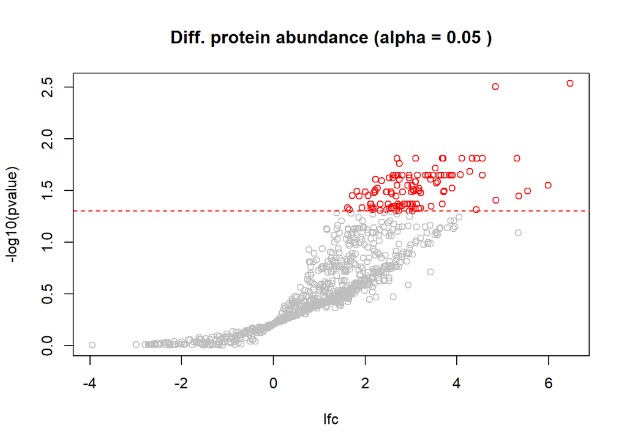

```r
plotVolcano(proteins_res,
            alpha
            )
```

Let’s now zoom on the FG-NUP proteins. The list is shown below :

```r
FGNupGroup <- c("RANBP2",
                "NUP214",
                "NUPL2",
                "NUP62",
                "NUP54",
                "NUPL1",
                "NUP98",
                "POM121",
                "POM121C",
                "NUP153",
                "NUP50")
kable(FGNupGroup)
```

| x |
| --- |
| RANBP2 |
| NUP214 |
| NUPL2 |
| NUP62 |
| NUP54 |
| NUPL1 |
| NUP98 |
| POM121 |
| POM121C |
| NUP153 |
| NUP50 |

From the volcano plot, we can see that these FG-NUP proteins are well represented in the domain of positive and significant log fold changes.

```r
proteins_res$set <- as.factor(ifelse(proteins_res$name %in% FGNupGroup,
                                     "FG-NUP",
                                     "Not_FG-NUP"))

FGNUP_proteins_res <- proteins_res[ proteins_res$set == "FG-NUP",]
knitr::kable(FGNUP_proteins_res[order(FGNUP_proteins_res$pval),
                              c("name", "diff", "pval", "adj_pval", "n_obs")] )
```

|  | name | diff | pval | adj_pval | n_obs |
| --- | --- | --- | --- | --- | --- |
| 367 | NUP98 | 4.841982 | 0.0000062 | 0.0031152 | 9 |
| 289 | NUP214 | 2.695796 | 0.0000846 | 0.0153917 | 9 |
| 295 | NUP62 | 5.311404 | 0.0000947 | 0.0153917 | 7 |
| 830 | NUPL1 | 4.429417 | 0.0001630 | 0.0153917 | 7 |
| 341 | NUP153 | 2.597608 | 0.0007989 | 0.0239158 | 9 |
| 776 | POM121 | 5.543849 | 0.0017622 | 0.0319445 | 6 |
| 652 | NUP54 | 4.849469 | 0.0029455 | 0.0391560 | 6 |
| 7 | POM121C | 4.045123 | 0.0070051 | 0.0572467 | 6 |
| 47 | NUPL2 | 5.342201 | 0.0140028 | 0.0809857 | 5 |
| 342 | RANBP2 | 1.296517 | 0.0378935 | 0.1499198 | 9 |
| 949 | NUP50 | 1.086998 | 0.0531983 | 0.1785816 | 9 |

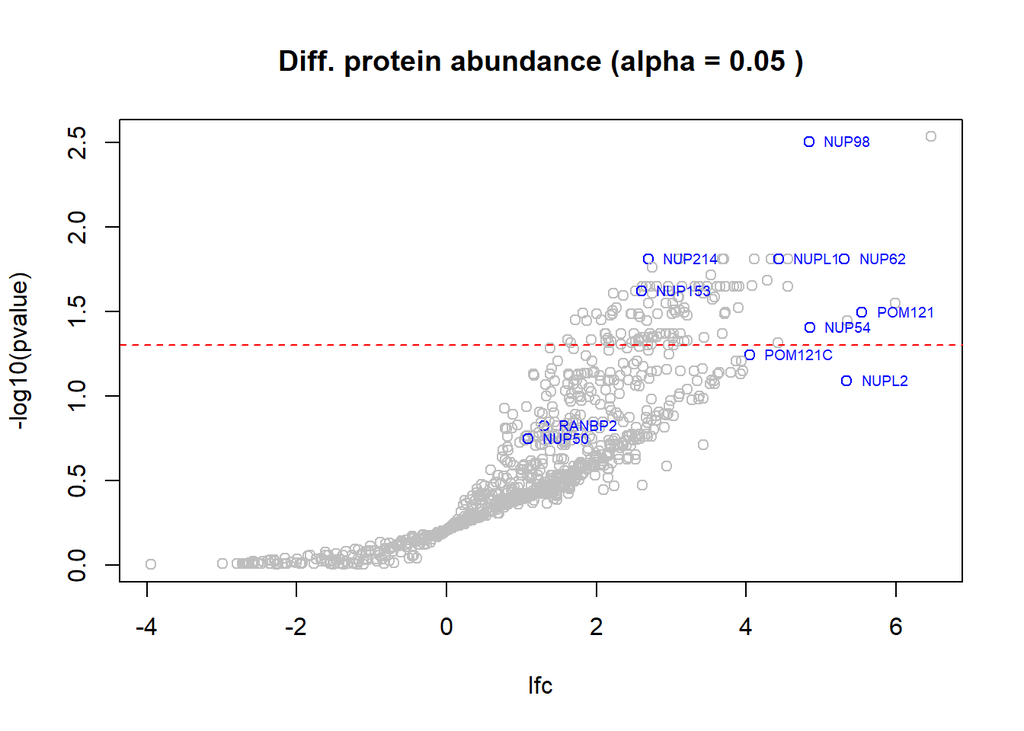

```r
plotVolcano( proteins_res,
             alpha = alpha,
             set2Highlight = "FG-NUP",
             highlightColor = "blue",
             displayHighlightedNames = TRUE
             )
```

The below shows the histogram of p-values. It shows a clear enrichment in the low end.

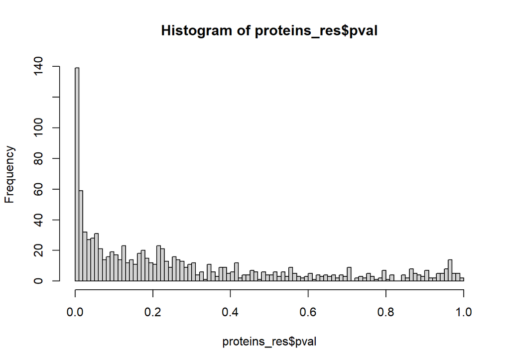

```r
hist(proteins_res$pval, breaks = 100)
```

### Wald test of F48A vs M60V

Here we test (in the reduced model) whether the group difference F48A vs M60V is significant. Again, we opt for a one-sided as we know that F48A group should have greater intensities, M60V being the negative control. We get :

- smallest p-vals around 10e-5 and adjusted p-val between 0.1% and 2.5%
- some protein abundances significantly differ at 5% level.

```r
grp_res2 <- test_diff( proDA_fit_norm,
                       contrast = "grpF48A",
                       alternative = "greater",
                       pval_adjust_method = "BH",
                       sort_by = NULL,
                       verbose = F )

dplyr::arrange(grp_res2, adj_pval) %>%
    head()
```

```
##     name         pval     adj_pval     diff t_statistic        se df
## 1 O60318 1.575361e-06 0.0009676151 7.184786   16.507304 0.4352489  6
## 2 P52948 1.941053e-06 0.0009676151 5.912783   15.931828 0.3711303  6
## 3 P35658 7.200847e-06 0.0023930813 4.151170   12.732291 0.3260348  6
## 4 P37198 3.581636e-05 0.0071417830 6.316868    9.633543 0.6557160  6
## 5 Q9BVL2 3.578376e-05 0.0071417830 5.814031    9.635088 0.6034227  6
## 6 P49790 1.452449e-04 0.0241348650 3.580159    7.500357 0.4773319  6
##   avg_abundance n_approx n_obs
## 1      7.405464 8.041732     8
## 2     11.602686 9.000000     9
## 3     10.127872 9.000000     9
## 4      6.735811 7.131891     7
## 5      7.439916 6.862105     7
## 6      9.697159 9.000000     9
```

We now provide a list of proteins that are significantly differentially abundant (F48A vs M60V), at 5% level (ordered by p-value). Here we only have 6 of such differentially abundant proteins!

We also display the corresponding volcano plot (highlighted for alpha = 5%).

```r
proteins_res2 <- grp_res2
proteins_res2$name <- fData( norm_log_x )$Gene.names

alpha <- 0.05

displaySignificantProteins(proteins_res2,
                           alpha)
```

```
## Significant at  5 % :  6 out of  997
```

|  | name | diff | pval | adj_pval | n_obs |
| --- | --- | --- | --- | --- | --- |
| 69 | MCM3AP | 7.184786 | 0.0000016 | 0.0009676 | 8 |
| 367 | NUP98 | 5.912783 | 0.0000019 | 0.0009676 | 9 |
| 289 | NUP214 | 4.151170 | 0.0000072 | 0.0023931 | 9 |
| 830 | NUPL1 | 5.814031 | 0.0000358 | 0.0071418 | 7 |
| 295 | NUP62 | 6.316868 | 0.0000358 | 0.0071418 | 7 |
| 341 | NUP153 | 3.580159 | 0.0001452 | 0.0241349 | 9 |

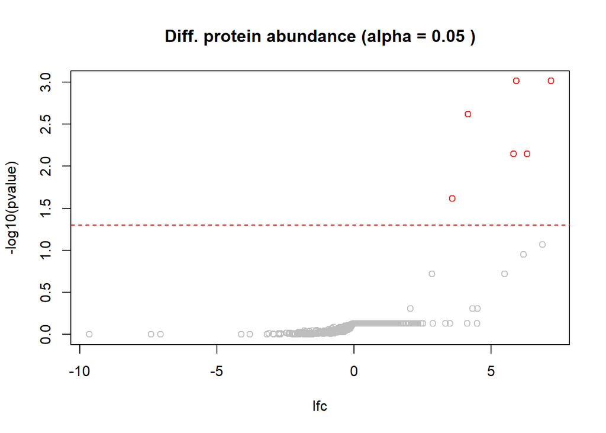

```r
plotVolcano(proteins_res2,
            alpha,
            displayHighlightedNames = FALSE
            )
```

Let’s now zoom again on FG-NUP proteins. From the volcano plot, we can see that, among the 6 significantly differentially abundant proteins, 5 belong to the this group.

```r
proteins_res2$set <- as.factor(ifelse(proteins_res$name %in% FGNupGroup,
                                     "FG-NUP",
                                     "Not_FG-NUP"))
FGNUP_proteins_res2 <- proteins_res2[ proteins_res$set == "FG-NUP",]
knitr::kable(FGNUP_proteins_res2[order(FGNUP_proteins_res$pval),
                              c("name", "diff", "pval", "adj_pval", "n_obs")] )
```

|  | name | diff | pval | adj_pval | n_obs |
| --- | --- | --- | --- | --- | --- |
| 367 | NUP98 | 5.9127835 | 0.0000019 | 0.0009676 | 9 |
| 289 | NUP214 | 4.1511696 | 0.0000072 | 0.0023931 | 9 |
| 295 | NUP62 | 6.3168684 | 0.0000358 | 0.0071418 | 7 |
| 830 | NUPL1 | 5.8140313 | 0.0000358 | 0.0071418 | 7 |
| 341 | NUP153 | 3.5801593 | 0.0001452 | 0.0241349 | 9 |
| 776 | POM121 | 6.8748238 | 0.0005979 | 0.0851618 | 6 |
| 652 | NUP54 | 6.1843093 | 0.0009025 | 0.1124726 | 6 |
| 7 | POM121C | 5.4886746 | 0.0017548 | 0.1916822 | 6 |
| 47 | NUPL2 | 4.4830838 | 0.0244602 | 0.7398060 | 5 |
| 342 | RANBP2 | -0.9082535 | 0.9084100 | 0.9693928 | 9 |
| 949 | NUP50 | -0.1010980 | 0.5673996 | 0.7945453 | 9 |

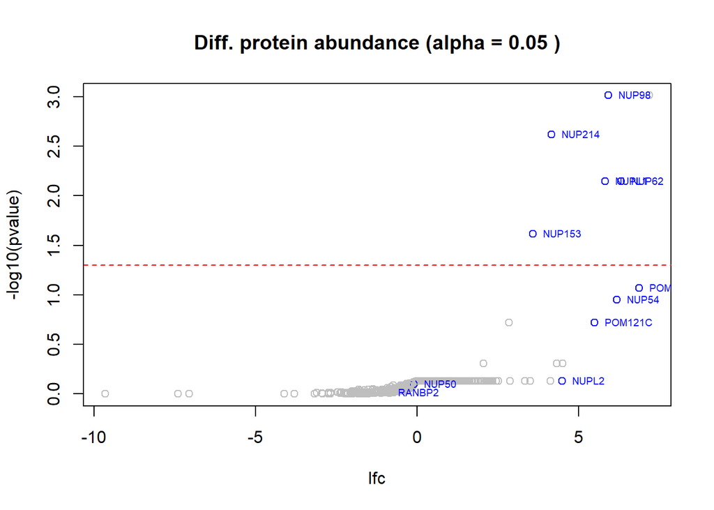

```r
plotVolcano( proteins_res2,
             alpha = alpha,
             set2Highlight = "FG-NUP",
             highlightColor = "blue",
             displayHighlightedNames = TRUE
             )
```

## Over Representation Analysis of the FG-NUP protein group (WT vs M60V)

### Using Fisher’s exact test (hyper-geometric distribution)

Let’s perform an over representation analysis of the FG-NUP proteins with respect to the other proteins. This is implemented as a Fisher’s exact test using the hyper-geometric distribution, also known as the ‘2X2 method’.

Here below is the corresponding contingency table. ‘DA’ stands for ‘Differentially abundant’. We classify the proteins into DA or not DA based on the adjusted p-value of the proDA analysis, and we select a treshhold of 0.05.

```r
DA_signif_threshold <- 0.05
fisher_input_data <- proteins_res[,c("name", "pval", "adj_pval", "set")]
fisher_input_data$DA <- as.factor( ifelse( fisher_input_data$adj_pval
                                           < DA_signif_threshold,
                                   "DA",
                                   "Not_DA") )

contingency_table <- table( fisher_input_data[,c("DA", "set")] )
knitr::kable(contingency_table)
```

|  | FG-NUP | Not_FG-NUP |
| --- | --- | --- |
| DA | 7 | 107 |
| Not_DA | 4 | 879 |

The Fisher exact test gives the below results. We reject the null hypothese (p-value = 4.8e-05) of independence of the two following events:

- a given protein being member of ‘FG-NUP’ group
- the same protein being differentially abundantin Wild vs M60V conditions.

Note that (we use a rather arbitrary threshold of 5% to classify between differentially abundant and not differentially abundant proteins)

```r
fisher_test <- fisher.test(x = contingency_table,
                           or = 1,
                           alternative = "two.sided",
                           conf.int = TRUE,
                           conf.level = 0.95)

fisher_test
```

```
##
##  Fisher's Exact Test for Count Data
##
## data:  contingency_table
## p-value = 4.8e-05
## alternative hypothesis: true odds ratio is not equal to 1
## 95 percent confidence interval:
##   3.567048 67.838139
## sample estimates:
## odds ratio
##   14.29897
```

### Using GSEA

There are several issues linked to Fisher’s test applied to post-hoc ORA (Over Representation Analysis) (see e.g. reference [1]), most important ones being :

- It uses an arbitrary significant threshold to classify between diffe - rentially abundant and not differentially abundant proteins (here 5% of adjusted p-value), and the result of the Fisher’s test is highly dependent on the threshold chosen.
- ORA implicitely assumes that each protein is independent from the other proteins (sample unit underlying the Fisher’s test is the proteins, not the initial experiment sample unit, and underlying assumption is that samples are i.i.d.)

In an attempt to address these issues, we implement a procedure similar to what is implemented in GSEA (for ‘Gene Set Enrichment Analysis’) software (see reference [2]).

We first calculate the Enrichment Score as well as showing the Enrichment Score path. The score is equal to 700. The Enrichment Score path shows a steep increase for the first proteins. Note that each proteins belonging to FG-NUP group adds 89 units to the score, while each proteins not belonging to FG-NUP group substract only one unit to the score.

```r
# the following function calculates an enrichment score (as in
# ref. [2] based a list of proteins with their pro-DA p-value (sorted
# according to decreasing p-value), and their set tags.
get_enrichment_score <- function(proteins_res, set) {
  ## order results set
    proteins_res <- proteins_res[ order( proteins_res$pval, decreasing = FALSE ), ]
    n_proteins <- nrow( proteins_res )
    n_proteins_in_set <- sum( proteins_res$set == set )
    set_ratio <- (n_proteins - n_proteins_in_set) / n_proteins_in_set
    set_indicators <- 1 * (proteins_res$set == set)
    prot.contributions <- -1 * rep(1, n_proteins) + (1 + set_ratio) * set_indicators
    path <- cumsum( prot.contributions )
    ES <- max( path )
    return( list( ES_path = path, ES = ES ) )
}
```

```r
ret <- get_enrichment_score( proteins_res, set = "FG-NUP" )
the_ES <- ret$ES
the_ES
```

```
## [1] 700
```

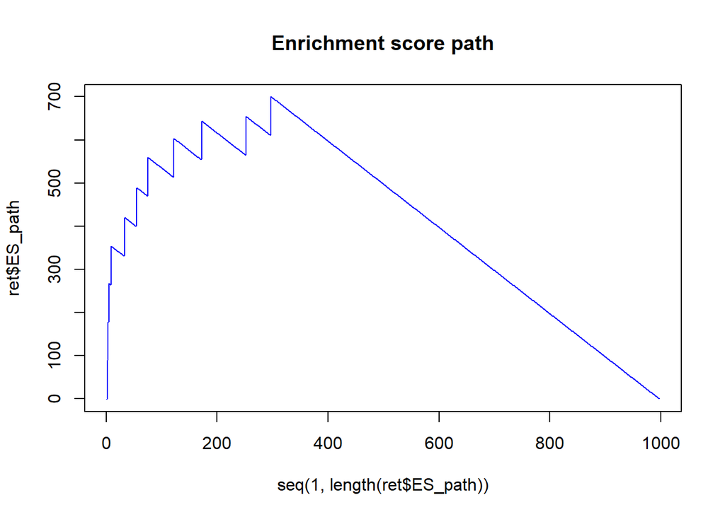

```r
#ret$ES_path

par( mfrow = c(1,1) )
plot( x = seq( 1, length( ret$ES_path ) ),
      y = ret$ES_path,
      type = "l",
      col = "blue",
      main = "Enrichment score path" )
```

```r
# the following function :
# - creates a random permutation of two sample groups (or identity permutation if 'do_permutation' == FALSE)
# - fits the proDA analysis based on the newly assigned abundances (including NA's)
# - calculates the p-val of the differential analysis for each gene
# - orders the gene by decreasing order of p-val (not adjusted)
# - calculates the Enrichment score as described in Ref. [2]

# input : 'experiment' : a MSnSet object containing the experiment data
#         'set' : the set variable (as a factor) for which to compute an enrichment score
#         'seed' : starting seed to generate the Monte Carlo simulation from
#         'contrast' : the contrast character to be used in the statistical test
one_permutation_enrichment_score <- function(experiment,
                                             set,
                                             seed,
                                             contrast,
                                             filePrefix,
                                             do_permutation = TRUE){
  set.seed(seed)

  groups <- pData(experiment)$grp
  nSamples <- length(groups)
  groupNames <- unique(groups)
  nGroups <- length(groupNames)

  groupSamples <- list()
  nInGroup <- rep(0L, nGroups)

  for(i in 1:nGroups){
    groupSamples[[i]] <- which(groups == groupNames[i])
    nInGroup[i] <- length(groupSamples[[i]])
  }

  # generate one permutation between all the groups
  permGroupSamples <- list()
  # keep the number of samples per group same as originally
  if ( do_permutation ) {
    samplesOrder <- sample(1:nSamples, nSamples, replace = FALSE)
    currentIndex <- 0
    for(i in 1:nGroups){
      permGroupSamples[[i]] <- samplesOrder[currentIndex
                                          + (1:nInGroup[i])]
      currentIndex <- currentIndex + nInGroup[i]
      permGroupSamples[[i]] <- sort(permGroupSamples[[i]])
    }

  } else {
    permGroupSamples <- groupSamples
  }

  permuted_experiment <- experiment
  for(i in 1:nGroups){
    pData(permuted_experiment)$grp[permGroupSamples[[i]]] <- groupNames[i]
  }
  #pData(permuted_experiment)

  # calling the proDA machinery

  suffix <- paste(permGroupSamples[[1]], collapse = "_")
  for(i in 2:nGroups){
    suffix <- paste0(suffix, "__")
    suffix <- paste0(suffix, paste(permGroupSamples[[i]], collapse = "_"))
  }
  file_name <- paste0( filePrefix, suffix, ".rds" )
  #file_name <- paste0( "./rds/GSEA/3groups/proDA_fit_norm_perm_", suffix, ".rds" )

  if (file.exists(file_name)){
    proDA_fit_norm_perm <- readRDS(file_name)
  } else {
    cat(" Running proDA model fitting with permutation", suffix, "\n")
    cat(" ***************************************************")
    proDA_fit_norm_perm <- proDA(permuted_experiment,
                                 design = ~ grp,
                                 data_is_log_transformed = TRUE,
                                 verbose = TRUE)

    saveRDS(proDA_fit_norm_perm, file = file_name)
  }

  # getting the proDA results
  perm_res <- test_diff( proDA_fit_norm_perm,
                       contrast = contrast,
                       alternative = "greater",
                       pval_adjust_method = "BH",
                       sort_by = NULL,
                       verbose = FALSE)
  perm_res$name <- fData(experiment)$Gene.names
  perm_res$set <- set
  ret <- get_enrichment_score(perm_res, set = levels(set)[1])
  ret
}
```

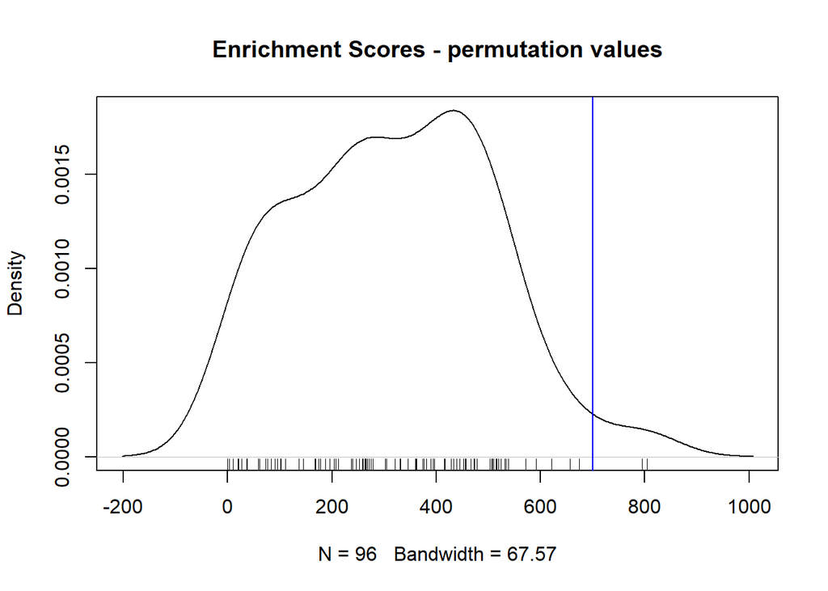

```r
file_name <- "./rds/GSEA/3groups/permutation_test_enrichscores_WT_vs_M60V.rds"
filePrefix <- "./rds/GSEA/3groups/proDA_fit_norm_perm_"
mySeed <- 20190512

if ( file.exists( file_name )) {
  ER_sample <- readRDS( file_name )
} else {
  n_permutations <- 100
  ER_sample <- rep(0, n_permutations)
  for (i in 1:n_permutations) {
      seed <- mySeed + i
      ret <- one_permutation_enrichment_score(norm_log_x,
                                              set = proteins_res$set,
                                              seed = seed,
                                              contrast = "grpWT",
                                              filePrefix = filePrefix,
                                              do_permutation = TRUE)
      ER_sample[i] <- ret$ES
  }

  saveRDS( ER_sample, file_name )
}

#hist( ER_sample, main = "Enrichment Score p-value")

#max( ER_sample )
ERS <- sort( unique( ER_sample ) )
## hist( ERS, main = "Enrichment Scores - permutation values")
plot( density(ERS), main = "Enrichment Scores - permutation values")
rug(ERS)
abline( v = the_ES, col = "blue" )
```

## Over Representation Analysis of the FG-NUP protein group (F48A vs M60V)

### Using Fisher’s exact test (hyper-geometric distribution)

Here below is the corresponding contingency table. Again, we classify the proteins into DA or not DA based on the adjusted p-value of the proDA analysis, and we select a treshold of 0.05.

```r
DA_signif_threshold <- 0.05
fisher_input_data2 <- proteins_res2[,c("name", "pval", "adj_pval", "set")]
fisher_input_data2$DA <- as.factor( ifelse( fisher_input_data2$adj_pval
                                            < DA_signif_threshold,
                                   "DA",
                                   "Not_DA") )

contingency_table2 <- table( fisher_input_data2[,c("DA", "set")] )
knitr::kable(contingency_table2)
```

|  | FG-NUP | Not_FG-NUP |
| --- | --- | --- |
| DA | 5 | 1 |
| Not_DA | 6 | 985 |

The Fisher exact test gives the below results. We reject the null hypothese (p-value = 3.4e-10) of independence of the two following events:

- a given protein being member of ‘FG-NUP’ group
- the same protein being differentially abundant in F48A vs M60V conditions.

```r
fisher_test2 <- fisher.test(x = contingency_table2,
                           or = 1,
                           alternative = "two.sided",
                           conf.int = TRUE,
                           conf.level = 0.95)

fisher_test2
```

```
##
##  Fisher's Exact Test for Count Data
##
## data:  contingency_table2
## p-value = 3.394e-10
## alternative hypothesis: true odds ratio is not equal to 1
## 95 percent confidence interval:
##  6.890993e+01 4.503600e+15
## sample estimates:
## odds ratio
##   732.9601
```

### Using GSEA

```r
ret2 <- get_enrichment_score( proteins_res2, set = "FG-NUP" )
the_ES2 <- ret2$ES
the_ES2
```

```
## [1] 794.7273
```

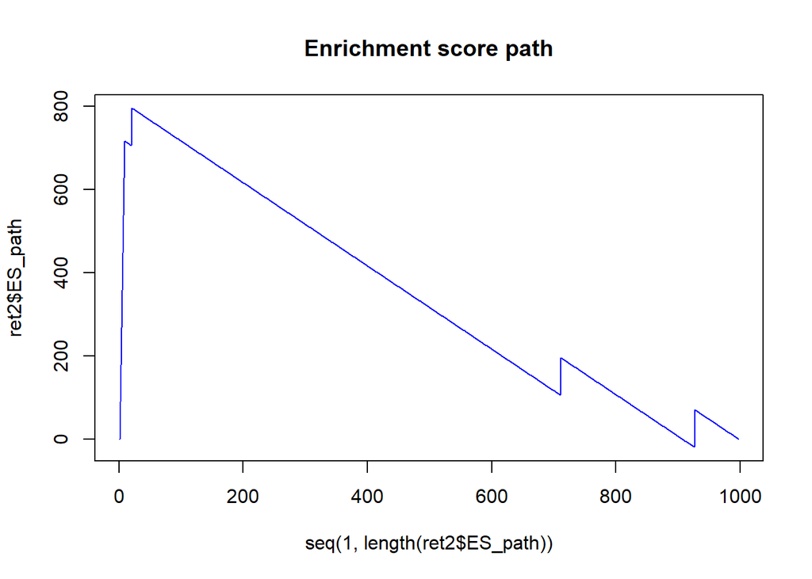

```r
#ret$ES_path

par( mfrow = c(1,1) )
plot( x = seq( 1, length( ret2$ES_path ) ),
      y = ret2$ES_path,
      type = "l",
      col = "blue",
      main = "Enrichment score path" )
```

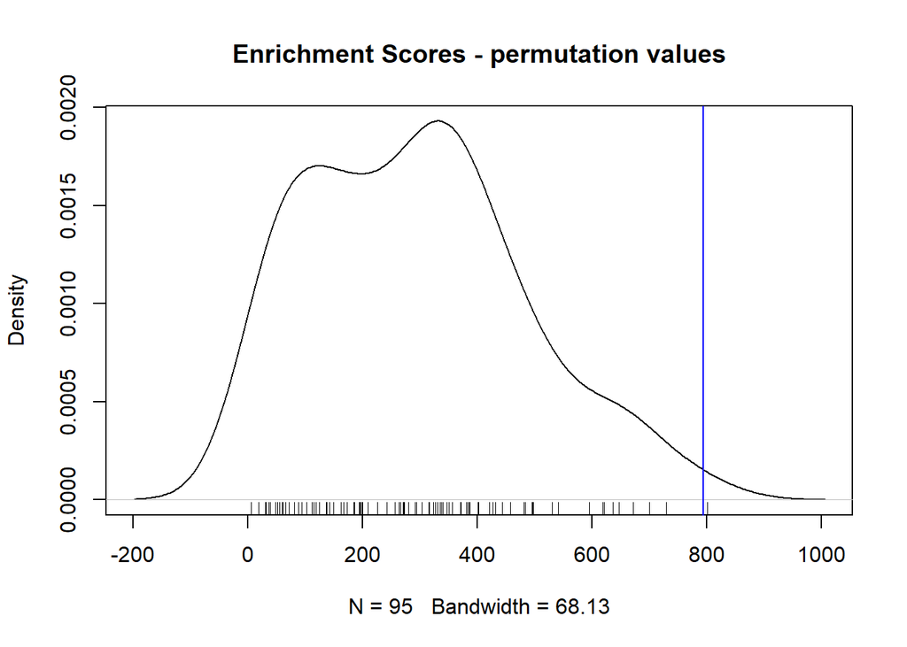

```r
file_name <- "./rds/GSEA/3groups/permutation_test_enrichscores_F48A_vs_M60V.rds"
filePrefix <- "./rds/GSEA/3groups/proDA_fit_norm_perm_"
mySeed <- 20190512

if ( file.exists( file_name )) {
  ER_sample <- readRDS( file_name )
} else {
  n_permutations <- 100
  ER_sample <- rep(0, n_permutations)
  for (i in 1:n_permutations) {
      seed <- mySeed + i
      ret <- one_permutation_enrichment_score(norm_log_x,
                                              set = proteins_res$set,
                                              seed = seed,
                                              contrast = "grpF48A",
                                              filePrefix = filePrefix,
                                              do_permutation = TRUE)
      ER_sample[i] <- ret$ES
  }

  saveRDS( ER_sample, file_name )
}

#hist( ER_sample, main = "Enrichment Score p-value")

#max( ER_sample )
ERS <- sort( unique( ER_sample ) )
## hist( ERS, main = "Enrichment Scores - permutation values")
plot( density(ERS), main = "Enrichment Scores - permutation values")
rug(ERS)
abline( v = the_ES2, col = "blue" )
```

## Export final results

Full export: normalised data and proDA results (for shiny app)

```r
fd <- fData(norm_log_x)[, c("Protein.IDs",
                            "Protein.names",
                            "Gene.names",
                            "nNA")]
norm_log_x1 <- norm_log_x
fd1 <- dplyr::full_join(fd, proteins_res, by = c("Gene.names" = "name"))
rownames(fd1) <- fd1[[1]]
fData(norm_log_x1) <- fd1
res1 <- ms2df(norm_log_x1)
res1$set[res1$set == "Not_FG-NUP"] <- NA
saveRDS(res1, file = "rds/res_expL_WT_vs_M60V.rds")

norm_log_x2 <- norm_log_x
fd2 <- dplyr::full_join(fd, proteins_res2, by = c("Gene.names" = "name"))
rownames(fd2) <- fd2[[1]]
fData(norm_log_x2) <- fd2
res2 <- ms2df(norm_log_x2)
res2$set[res2$set == "Not_FG-NUP"] <- NA
saveRDS(res2, file = "rds/res_expL_F48A_vs_M60V.rds")
```

## References

[1] Goeman, Jelle J., and Peter Bühlmann. 2007. “Analyzing Gene Expression Data in Terms of Gene Sets: Methodological Issues.” Bioinformatics 23 (8): 980-87.

[2] Subramanian, Aravind, Pablo Tamayo, Vamsi K. Mootha, Sayan Mukherjee, Benjamin L. Ebert, Michael A. Gillette, Amanda Paulovich, et al. 2005. “Gene Set Enrichment Analysis: A Knowledge-Based Approach for Interpreting Genome-Wide Expression Profiles.” Proceedings of the National Academy of Sciences of the United States of America 102 (43): 15545-50.